# [Possible] Factors for the Recent Surge of Fake Accounts

Matthew Romero  
matmat.romero@gmail.com

# Introduction

In the morning of June 07, 2020, Facebook users woke up to find fake profiles resembling themselves. Some of whom had little to no friends in it, while some fake profiles imitated the personalities of the real profiles they copied. The reality was that everyone could've been a victim. People were clueless as to how this happened. This very simple and minute study sought to determine the correlation between some common political behaviors that led to these individuals to become a victim of these fake profiles.

```python
import numpy as np
import pandas as pd
import matplotlib.pyplot as plt
import mglearn
from sklearn.neighbors import KNeighborsClassifier
from sklearn.model_selection import train_test_split
from sklearn.model_selection import cross_val_score
from scipy.stats import chi2_contingency

pass
```

The responses to this study was gathered using Microsoft Forms. [(The questionnaire can be found here)](https://forms.office.com/Pages/ResponsePage.aspx?id=Zz3KImWBbke5GEsuMeBHup_9C11ArKVNu6u3wzXcwPxURjFVUjBMVzc3WTlYMTVEQkhESFNBRUYwUi4u) Afterwards, the responses were saved in a csv file to be processed here.

**Assumption**: Responses were collected anonmyously and each user were not limited to one answer only. There is no way of knowing if a certain user had multiple answers to this questionnaire. This could decrease the reliability of this test.

The following questions were asked to the respondents:

- Did you sign the junk terror bill online petition?
- Did you post something with the hashtag #JunkTerrorBill?
- Are/Were you a part of the Big 4 trashtalkan Facebook group?
- Are you a victim of the recent rise of fake accounts on Facebook?

The first 3 statements refer to the possible factor that led to the fake profile creation, and the latter was asked to check if they were a victim or not.

```python
df = pd.read_csv('trolls.csv',
                 usecols=[5,6,7,8]).dropna().reset_index(drop=True)
df.head()
```

|  | Did you sign the junk terror bill online petition? | Did you post something with the hashtag #JunkTerrorBill? | Are/Were you a part of the Big 4 trashtalkan Facebook group? | Are you a victim of the recent rise of fake accounts on Facebook? |
| --- | --- | --- | --- | --- |
| 0 | No | Yes | No | No |
| 1 | No | No | Yes | Yes |
| 2 | Yes | Yes | Yes | Yes |
| 3 | No | No | No | No |
| 4 | No | Yes | Yes | No |

The column headers of the dataset were renamed for easier processing.

```python
df.columns = ['sign_petition', 'post_terrorbill', 'part_bigfour', 'victim']
df.head()
```

|  | sign_petition | post_terrorbill | part_bigfour | victim |
| --- | --- | --- | --- | --- |
| 0 | No | Yes | No | No |
| 1 | No | No | Yes | Yes |
| 2 | Yes | Yes | Yes | Yes |
| 3 | No | No | No | No |
| 4 | No | Yes | Yes | No |

Using the `df.shape` method, the number of samples could be counted.

```python
df.shape
```

```
(136, 4)
```

There are `136` samples in this data set.

# Chi-Square Test

In dealing with categorical data, the Chi-Square is used to test the correlation between the independent categorical features of a dataset to the outcome. In this case, we're testing if the 3 features `sign_petition`, `post_terrorbill`, `part_bigfour` had a hand in determining if one is a `victim`.

Before analyzing the dataset via Chi-Square Test, the samples were counted per feature:

```python
df1 = df.apply(pd.value_counts)
df1
```

|  | sign_petition | post_terrorbill | part_bigfour | victim |
| --- | --- | --- | --- | --- |
| No | 84 | 72 | 70 | 69 |
| Yes | 52 | 64 | 66 | 67 |

The dataset then was analyzed using the chi-square distribution of Scipy which is `chi2_contingency`.

```python
chi2_contingency(df1)
```

```
(4.288013069226056,
 0.23199650691088683,
 3,
 array([[73.75, 73.75, 73.75, 73.75],
        [62.25, 62.25, 62.25, 62.25]]))
```

We see a high p-value at 0.2319. This tells us that the features don't dictate who becomes a victim.

This is also shown here below.

```python
chi2, p, dof, ex = chi2_contingency(df1, correction=True)
print(f"Chi2 result of the contingency table: {chi2}, p-value: {p}")
```

```
Chi2 result of the contingency table: 4.288013069226056, p-value: 0.23199650691088683
```

We can actually make the conclusion that it doesn't matter what you did on Facebook; whether you signed the petition against the anti-terrorism bill, posted something against the anti-terrorism bill with the hashtag #JunkTerrorBill, or if you joined the Big 4 Trashtalkan Fb group, anyone could've a victim.

# kNN Classifier

Even though the correlations are weak, let's try to extend this further by determining which of these activities led to the individuals being victimized via machine learning. For this data set, we will be using the k-Nearest Neighbors Classifier.

A bit of data cleaning was done for better processing later on. The dataframe was renamed to `df_trolls` and the values were replaced with `1` and `0`, corresponding to `Yes` and `No` respectively.

```python
df_TROLLS = df
```

```python
df_TROLLS = df_TROLLS.replace(['Yes', 'No'], [1,0])
```

```python
df_TROLLS.head()
```

|  | sign_petition | post_terrorbill | part_bigfour | victim |
| --- | --- | --- | --- | --- |
| 0 | 0 | 1 | 0 | 0 |
| 1 | 0 | 0 | 1 | 1 |
| 2 | 1 | 1 | 1 | 1 |
| 3 | 0 | 0 | 0 | 0 |
| 4 | 0 | 1 | 1 | 0 |

```python
dummy = df_TROLLS
```

```python
df_features = dummy.drop('victim', axis=1)
df_features.head()
```

|  | sign_petition | post_terrorbill | part_bigfour |
| --- | --- | --- | --- |
| 0 | 0 | 1 | 0 |
| 1 | 0 | 0 | 1 |
| 2 | 1 | 1 | 1 |
| 3 | 0 | 0 | 0 |
| 4 | 0 | 1 | 1 |

```
Highest possible accuracy for this model: 0.5294117647058824
```

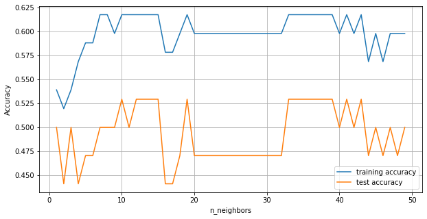

```python
X_train, X_test, y_train, y_test = train_test_split(df_features,df_TROLLS['victim'],
                                                    test_size=0.25,random_state=1)

training_accuracy = []
test_accuracy = []
neighbors_settings = range(1, 50) # try n_neighbors from 1 to 50

for n_neighbors in neighbors_settings:
    clf = KNeighborsClassifier(n_neighbors=n_neighbors)  # build the model
    clf.fit(X_train, y_train)

    training_accuracy.append(clf.score(X_train, y_train)) # record training set accuracy
    test_accuracy.append(clf.score(X_test, y_test))   # record generalization accuracy

plt.figure(figsize=(10,5))
plt.plot(neighbors_settings, training_accuracy, label="training accuracy")
plt.plot(neighbors_settings, test_accuracy, label="test accuracy")
plt.ylabel("Accuracy")
plt.xlabel("n_neighbors")
plt.legend()
plt.grid()
print("Highest possible accuracy for this model: {}".format(max(test_accuracy)))
pass
```

```python
df_TROLLS.head()
```

|  | sign_petition | post_terrorbill | part_bigfour | victim |
| --- | --- | --- | --- | --- |
| 0 | 0 | 1 | 0 | 0 |
| 1 | 0 | 0 | 1 | 1 |
| 2 | 1 | 1 | 1 | 1 |
| 3 | 0 | 0 | 0 | 0 |
| 4 | 0 | 1 | 1 | 0 |

```python
a = df_TROLLS['victim'].to_numpy()
print(a)
b = df_TROLLS[['sign_petition', 'post_terrorbill', 'part_bigfour']].to_numpy()
```

```
[0 1 1 0 0 0 0 1 1 0 0 0 0 0 0 0 0 1 1 0 0 1 0 0 0 1 0 0 0 1 1 1 0 1 1 1 1
 0 1 1 0 0 1 1 0 0 0 0 1 0 1 0 0 1 0 0 0 0 1 1 1 0 1 0 0 1 0 1 1 1 0 1 0 1
 1 0 1 0 1 1 0 1 1 0 0 0 0 1 1 0 0 0 1 0 0 1 1 1 0 1 1 0 0 0 0 1 1 1 1 0 1
 0 1 0 0 0 1 1 1 1 1 1 1 1 1 0 1 0 1 1 1 0 1 1 0 0]
```

```python
data = {
    'target': (a),
    'data': (b),
    'feature_names':['sign_petition', 'post_terrorbill', 'part_bigfour'],
    'target_names':np.asarray(('No', 'Yes'))
}
c = data
```

```python
X_train, X_test, y_train, y_test = train_test_split(
    c['data'], c['target'],test_size=0.30,
    random_state=2)
```

```python
print("X_train shape: {}".format(X_train.shape))
print("Y_train shape: {}".format(y_train.shape))
```

```
X_train shape: (95, 3)
Y_train shape: (95,)
```

```python
print("X_test shape: {}".format(X_test.shape))
print("Y_test shape: {}".format(y_test.shape))
```

```
X_test shape: (41, 3)
Y_test shape: (41,)
```

```python
knn = KNeighborsClassifier(n_neighbors=10)
```

```python
knn.fit(X_train, y_train)
```

```
KNeighborsClassifier(algorithm='auto', leaf_size=30, metric='minkowski',
                     metric_params=None, n_jobs=None, n_neighbors=10, p=2,
                     weights='uniform')
```

## Test cases for the model

```python
data['feature_names']
```

```
['sign_petition', 'post_terrorbill', 'part_bigfour']
```

```python
# Individual did not sign the petition, did not post #JunkTerrorBil, is not in Big 4 trashtalk group
X_new = np.array([[0,0,0]])
prediction = knn.predict(X_new)
print("Prediction: {}".format(prediction))
print("Victim? {}".format(
       c['target_names'][prediction]))
```

```
Prediction: [0]
Victim? ['No']
```

```python
# Individual signed the petition, posted #JunkTerrorBil, is in Big 4 trashtalk group
X_new = np.array([[1,1,1]])
prediction = knn.predict(X_new)
print("Prediction: {}".format(prediction))
print("Victim? {}".format(
       c['target_names'][prediction]))
```

```
Prediction: [1]
Victim? ['Yes']
```

```python
# Individual signed the petition, did not post #JunkTerrorBil, is not in Big 4 trashtalk group
X_new = np.array([[1,0,0]])
prediction = knn.predict(X_new)
print("Prediction: {}".format(prediction))
print("Victim? {}".format(
       c['target_names'][prediction]))
```

```
Prediction: [1]
Victim? ['Yes']
```

```python
# Individual did not sign the petition, posted #JunkTerrorBil, is in Big 4 trashtalk group
X_new = np.array([[0,1,1]])
prediction = knn.predict(X_new)
print("Prediction: {}".format(prediction))
print("Victim? {}".format(
       c['target_names'][prediction]))
```

```
Prediction: [0]
Victim? ['No']
```

Now testing the `test_set` and comparing it with our original test set.

```python
y_pred = knn.predict(X_test)
print("Test set predictions:\n {}".format(np.array(y_pred).tolist()))

print("Original predictions:\n {}".format(np.array(y_test).tolist()))
```

[output not shown]

```python
# clf = KNeighborsClassifier()
# y =  c['target']
# number_features = c['data'].shape[1]
# print(c['feature_names'])
# print('Feature  Accuracy')
# for i in range(number_features):
#     X = c['data'][:, i].reshape(-1, 1)
#     scores = cross_val_score(clf, X, y)
#     print('%d        %g' % (i, scores.mean()))
```

[output not shown]

```python
# print('Feature  Accuracy')
# for i in range(number_features):
#     X_head = np.atleast_2d(c['data'][:, 0:i])
#     X_tail = np.atleast_2d(c['data'][:, i+1:])
#     X = np.hstack((X_head, X_tail))
#     scores = cross_val_score(clf, X, y)
#     print('%d        %g' % (i, scores.mean()))
```

[output not shown]